# Pleiotropy Investigation

05 September, 2025

### Questions to attempt to answer:

1. Association vs. colocalization: how often do we see a genetic association with a trait that doesn’t have a coloc result?
   - Prevelance of H3 > 0.8 vs. H4 > 0.8
2. How many coloc groups have only qtls? QTL and phenotype, QTL and multiple phenotypes
3. How many of these chosen causal SNPs are in LD with each other?
4. Modularity of pleiotropy
   - How can we quantify modularity?
   - How many genes are associated with a trait on average?
   - Does it change when including trans-QTLs?
   - What about gene-gene modularity? Could we have a graph where we count the number of associations between genes tagged?
   - Genes that colocalise with the most traits (or trait categories?).
5. What fraction of known GWAS hits are no known molecular trait associated with it?
6. Is there consistency between of molecule-disease associations between common cis, rare cis and trans instruments?
7. Can we calculate a ‘pleiotropy score’ for each SNP? Would it be useful?

## Apparent pleiotropy due to LD

Association vs. colocalization: How often would we see a genetic association with a trait that doesn’t have a coloc result?

For any causal variant:

| trait | num_significant_h4 | num_spurious_h4 | num_significant_h3 | h3_h4_ratio |
| --- | --- | --- | --- | --- |
| All | 58717938 | 2833453 | 238339473 | 4.059057 |
| Hemoglobin | 32695 | 1529 | 143142 | 4.378101 |

#### Breakdown of ratio of h3 to h4 by data type

Number of H4 > 0.8 between data types

|  | methylation | phenotype | gene_expression | protein | splice_variant |
| --- | --- | --- | --- | --- | --- |
| methylation | 255,088 | 351,231 | 794,369 | 41,536 | 930,327 |
| phenotype | NA | 4,208,613 | 1,644,455 | 1,252,027 | 2,210,878 |
| gene_expression | NA | NA | 6,882,803 | 231,672 | 12,685,794 |
| protein | NA | NA | NA | 1,052,027 | 354,830 |
| splice_variant | NA | NA | NA | NA | 25,822,288 |

Number of H3 > 0.8 between data types

|  | methylation | phenotype | gene_expression | protein | splice_variant |
| --- | --- | --- | --- | --- | --- |
| methylation | 2,076,586 | 4,573,373 | 9,454,094 | 1,038,089 | 13,897,918 |
| phenotype | NA | 9,305,711 | 14,721,615 | 3,729,227 | 22,638,824 |
| gene_expression | NA | NA | 22,592,531 | 3,611,022 | 63,962,222 |
| protein | NA | NA | NA | 1,125,090 | 5,777,702 |
| splice_variant | NA | NA | NA | NA | 59,834,564 |

Ratio of H3 > 0.8 to H4 > 0.8 between data types

|  | methylation | phenotype | gene_expression | protein | splice_variant |
| --- | --- | --- | --- | --- | --- |
| methylation | 8.140665 | 13.020983 | 11.901388 | 24.992513 | 14.938745 |
| phenotype | NA | 2.211111 | 8.952276 | 2.978552 | 10.239744 |
| gene_expression | NA | NA | 3.282461 | 15.586787 | 5.042035 |
| protein | NA | NA | NA | 1.069450 | 16.283014 |
| splice_variant | NA | NA | NA | NA | 2.317167 |

## Unpacking Spurious colocalizations

### Spurious colocalization rate by h4 score

Is there a relationship between the h4 score and the spuriousness of the colocalization? If h4 > 0.8 too lenient?

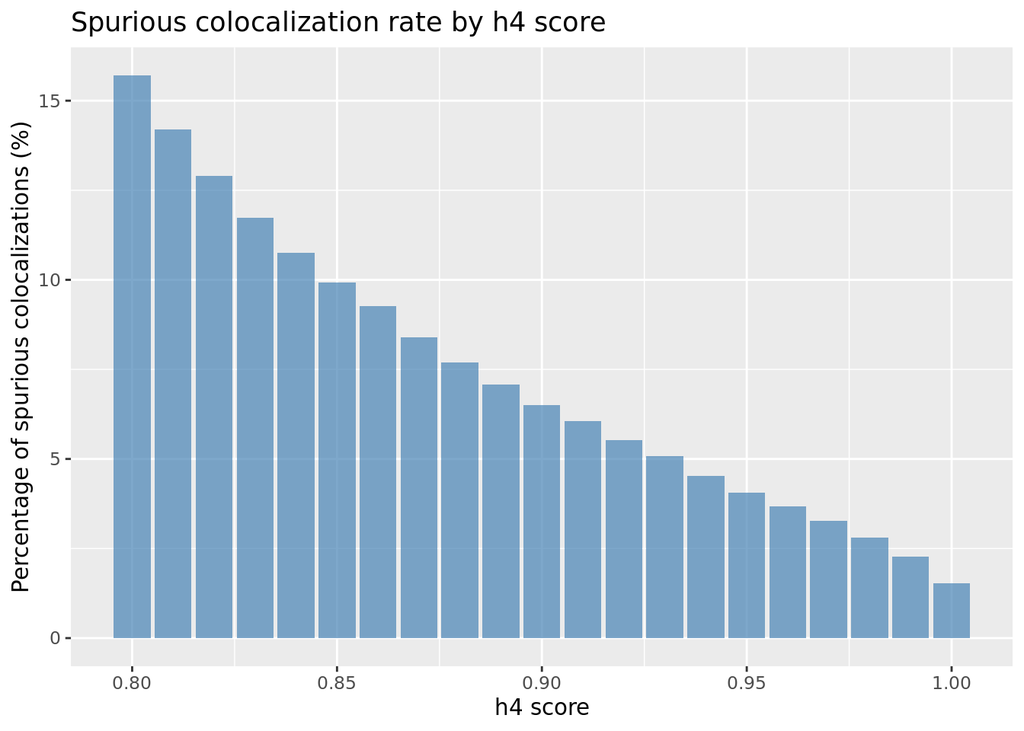

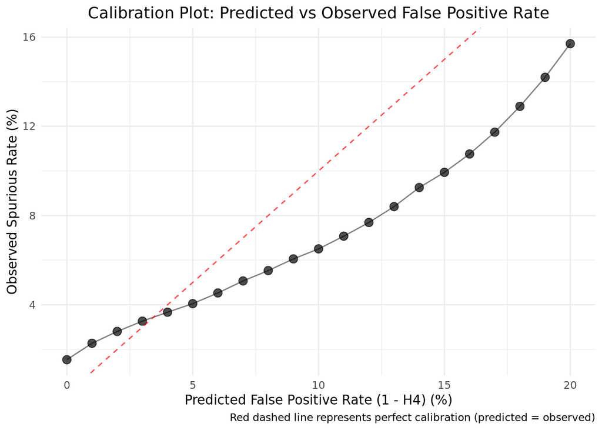

### Spurious colocalization rate by data type

[figure not shown]

## How often does a coloc group have multiple genes? Multiple phenotypes? (cis only)

Number of coloc groups by unique genes and phenotypes (methQTL are neither genes nor phenotypes)

| genes_bin | No phenotypes | 1 phenotypes | 2 phenotypes | 3 phenotypes | 4 phenotypes | 5 phenotypes | >5 phenotypes |
| --- | --- | --- | --- | --- | --- | --- | --- |
| No genes | 10319 | 2590 | 10975 | 4597 | 2371 | 1371 | 4340 |
| 1 genes | 34802 | 8093 | 3039 | 1557 | 932 | 670 | 2547 |
| 2 genes | 21314 | 3017 | 1302 | 685 | 412 | 292 | 1171 |
| 3 genes | 7833 | 1358 | 604 | 347 | 198 | 176 | 685 |
| 4 genes | 3354 | 668 | 299 | 187 | 142 | 90 | 352 |
| 5 genes | 1645 | 348 | 172 | 95 | 55 | 50 | 206 |
| >5 genes | 2128 | 508 | 263 | 139 | 119 | 89 | 400 |

Percentage of coloc groups by unique genes and phenotypes (methQTL are neither genes nor phenotypes)

| genes_bin | No phenotypes | 1 phenotypes | 2 phenotypes | 3 phenotypes | 4 phenotypes | 5 phenotypes | >5 phenotypes |
| --- | --- | --- | --- | --- | --- | --- | --- |
| No genes | 7.43% | 1.86% | 7.90% | 3.31% | 1.71% | 0.99% | 3.12% |
| 1 genes | 25.05% | 5.83% | 2.19% | 1.12% | 0.67% | 0.48% | 1.83% |
| 2 genes | 15.34% | 2.17% | 0.94% | 0.49% | 0.30% | 0.21% | 0.84% |
| 3 genes | 5.64% | 0.98% | 0.43% | 0.25% | 0.14% | 0.13% | 0.49% |
| 4 genes | 2.41% | 0.48% | 0.22% | 0.13% | 0.10% | 0.06% | 0.25% |
| 5 genes | 1.18% | 0.25% | 0.12% | 0.07% | 0.04% | 0.04% | 0.15% |
| >5 genes | 1.53% | 0.37% | 0.19% | 0.10% | 0.09% | 0.06% | 0.29% |

### Distinct phenotype categories in the same coloc group

How can we quantify the pleiotropy of phenotypes, when different phenotypes can be so similar? How else can we quantify biological pleiotropy (vs. LD)?

Distinct trait categories in the same coloc group

| trait_category_bin | count |
| --- | --- |
| 1 trait categories | 33574 |
| 2 trait categories | 18287 |
| 3 trait categories | 4023 |
| 4 trait categories | 1125 |
| 5 trait categories | 346 |
| 6 trait categories | 125 |
| 7 trait categories | 31 |

Example coloc group with multiple trait categories

| trait_category | trait_name |
| --- | --- |
| Health Trait / Disease Outcome | Lung cancer in ever smokers |
| Clinical Measure | Epstein-Barr virus EA-D antibody levels |
| Clinical Measure | Varicella zoster virus glycoproteins E and I antibody levels |
| Health Trait / Disease Outcome | IgA nephropathy |
| Health Trait / Disease Outcome | Nephrotic syndrome |
| Health Trait / Disease Outcome | Autoimmune hepatitis |
| Health Trait / Disease Outcome | Hyperthyroidism |
| Blood Cell Measure | IgD on IgD+ CD38- unswitched memory B cell |
| Health Trait / Disease Outcome | Sjögren’s syndrome |
| Social / Behavioural | Moderate to vigorous physical activity levels |
| Blood Cell Measure | Hemoglobin concentration |
| Blood Cell Measure | Mean spheric corpuscular volume |
| Blood Cell Measure | Hematocrit |
| Blood Cell Measure | Plateletcrit |
| Anthropometric | Appendicular lean mass |
| Blood Cell Measure | Red blood cell count |
| Blood Cell Measure | Reticulocyte fraction of red cells |
| Blood Cell Measure | Monocyte count |
| Social / Behavioural | Seen psychiatrist for nerves anxiety tension or depression (UKB data field 2100) (SPA correction) |
| Health Trait / Disease Outcome | Illnesses of father: Lung cancer |
| Health Trait / Disease Outcome | Other serious medical condition/disability diagnosed by doctor |
| Social / Behavioural | Number of days/week of moderate physical activity 10+ minutes |
| Health Trait / Disease Outcome | Early-onset myasthenia gravis |
| Physiological | Time to complete round |
| Operation / Treatment | Medication for pain relief, constipation, heartburn: Paracetamol |
| Social / Behavioural | Seen psychiatrist for nerves anxiety tension or depression (UKB data field 2100) (Firth correction) |
| Operation / Treatment | Medication for pain relief, constipation, heartburn: None of the above |
| Health Trait / Disease Outcome | Seen a psychiatrist for nerves, anxiety, tension or depression |
| Health Trait / Disease Outcome | Any parental history of lung cancer (Firth correction) |
| Operation / Treatment | Operation code: varicose vein surgery |
| Health Trait / Disease Outcome | Any parental history of lung cancer (SPA correction) |
| Health Trait / Disease Outcome | Diagnoses - main ICD10: R31 Unspecified haematuria |
| Anthropometric | Leg predicted mass (right) |
| Health Trait / Disease Outcome | Non-cancer illness code, self-reported: hyperthyroidism/thyrotoxicosis |
| Social / Behavioural | Place of birth in UK - north co-ordinate |
| Anthropometric | Ankle spacing width |
| Social / Behavioural | Nervous feelings |
| Anthropometric | Leg fat-free mass (right) |
| Clinical Measure | Diastolic blood pressure automated reading (UKB data field 4079) |
| Anthropometric | Whole body fat-free mass |
| Clinical Measure | Calcium levels (UKB data field 30680) |
| Anthropometric | Ankle spacing width (left) |
| Anthropometric | Trunk fat mass |
| Clinical Measure | Gamma glutamyltransferase levels (UKB data field 30730) |
| Anthropometric | Sitting height |
| Anthropometric | Leg predicted mass (left) |
| Clinical Measure | Aspartate aminotransferase levels (UKB data field 30650) |
| Clinical Measure | Impedance of leg (left) |
| Blood Cell Measure | Monocyte count (UKB data field 30130) |
| Anthropometric | Trunk fat-free mass |
| Anthropometric | Arm predicted mass (right) |
| Blood Cell Measure | Platelet count (UKB data field 30080) |
| Clinical Measure | Cystatin C levels (UKB data field 30720) |
| Anthropometric | Leg fat-free mass (left) |
| Anthropometric | Arm fat-free mass (left) |
| Anthropometric | Arm fat-free mass (right) |
| Anthropometric | Whole body water mass |
| Health Trait / Disease Outcome | Diseases of the blood and blood-forming organs and certain disorders involving the immune mechanism |
| Health Trait / Disease Outcome | Cancer of primary lymphoid hematopoietic |
| Operation / Treatment | Operative procedures - main OPCS: G45.1 Fibreoptic endoscopic examination of upper gastrointestinal tract and biopsy of lesion of upper gastrointestinal tract |
| Health Trait / Disease Outcome | Lymphomas |
| Health Trait / Disease Outcome | Other diseases of the digestive system |
| Health Trait / Disease Outcome | Endocrine, nutritional and metabolic diseases |
| Blood Cell Measure | Platelet crit |
| Anthropometric | Ankle spacing width (right) |
| Blood Cell Measure | Red blood cell (erythrocyte) distribution width |
| Health Trait / Disease Outcome | Non-cancer illness code, self-reported: malabsorption/coeliac disease |
| Clinical Measure | Diastolic blood pressure, automated reading |
| Clinical Measure | Impedance of leg (right) |
| Anthropometric | Arm predicted mass (left) |
| Anthropometric | Trunk predicted mass |

SNP in question: https://gpmap.opengwas.io/snp.html?id=7790443

### Breakdown of coloc groups by number of genes

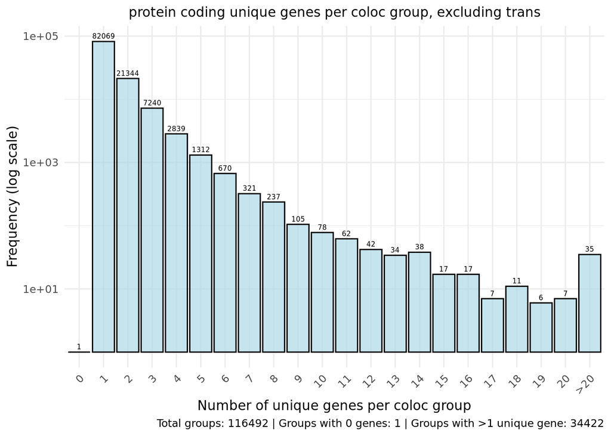

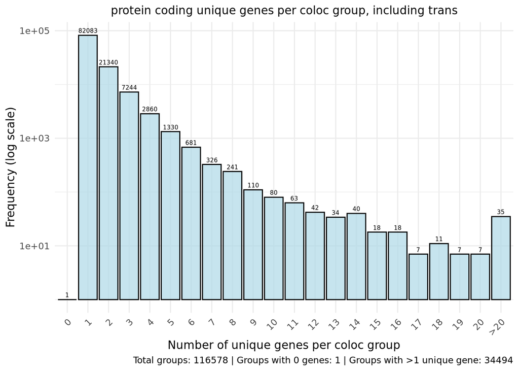

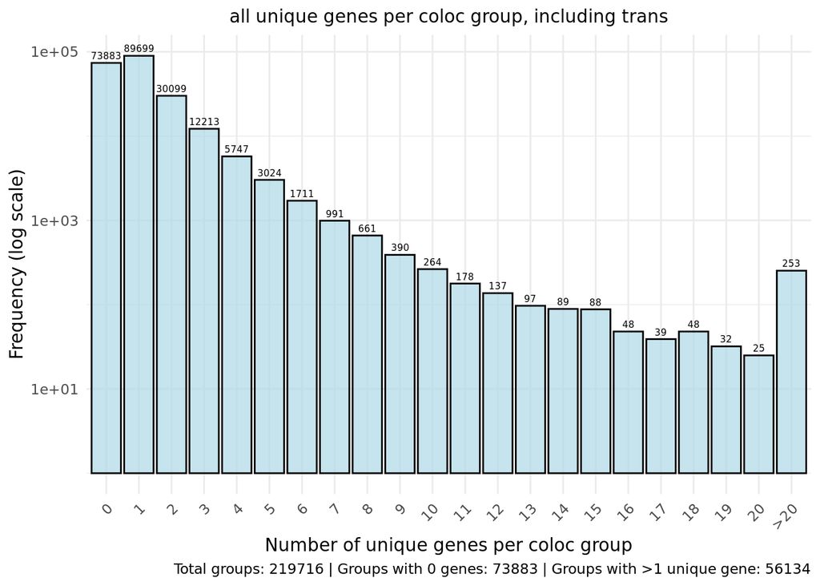

## Genes that colocalise with the most traits (or trait categories?).

Limited to cis-coloc pairs with h4 > 0.8 and p-values < 1e-8.

Genes that colocalise with the most traits

| gene | num_traits |
| --- | --- |
| HLA-DRB5 | 437 |
| HLA-DRB1 | 433 |
| HLA-B | 399 |
| ABO | 368 |
| HLA-C | 346 |
| FADS1 | 336 |
| FADS2 | 335 |
| TMEM258 | 333 |
| ENSG00000289268 | 315 |
| HLA-L | 301 |
| HLA-DQA1 | 300 |
| MLXIPL | 292 |
| FEN1 | 283 |
| SORT1 | 279 |
| GSTM1 | 278 |
| CELSR2 | 273 |
| PSRC1 | 273 |
| CTA-315H11 | 260 |
| NECTIN2 | 257 |
| C11orf10 | 254 |
| HLA-DQA2 | 241 |
| SCN2A | 236 |
| HLA-H | 235 |
| LIPC | 234 |
| FBXO46 | 233 |
| LPL | 232 |
| HLA-A | 227 |
| HLA-DQB1 | 222 |
| HLA-DQB2 | 216 |
| APOC2 | 206 |
| IRS1 | 205 |
| CETP | 201 |
| PLTP | 197 |
| CYP21A2 | 195 |
| MAMSTR | 195 |
| SLC12A3 | 193 |
| RP11-395N3 | 190 |
| FUT2 | 182 |
| ZNF335 | 182 |
| ENSG00000285796 | 178 |
| HP | 176 |
| PCSK9 | 176 |
| RP11-115J16 | 176 |
| NTN5 | 175 |
| APOE | 170 |
| AL162458 | 168 |
| CYP21A1P | 167 |
| ABCG5 | 166 |
| HLA-DRB6 | 163 |
| HPR | 163 |

Phenotypes for top gene: HLA-DRB5

| gene | trait |
| --- | --- |
| HLA-DRB5 | Sum eosinophil basophil counts |
| HLA-DRB5 | HLA DR on CD14- CD16+ monocyte |
| HLA-DRB5 | Allergic rhinitis (Firth correction) |
| HLA-DRB5 | Linoleic acid levels |
| HLA-DRB5 | Phospholipids to total lipids ratio in medium LDL |
| HLA-DRB5 | Omega-6 fatty acid levels |
| HLA-DRB5 | Angina pectoris |
| HLA-DRB5 | Phosphoglycerides levels |
| HLA-DRB5 | Basal cell carcinoma |
| HLA-DRB5 | Skin cancer |
| HLA-DRB5 | Free cholesterol levels in IDL |
| HLA-DRB5 | Free cholesterol to total lipids ratio in large VLDL |
| HLA-DRB5 | Diagnoses - main ICD10: C44.3 Skin of other and unspecified parts of face |
| HLA-DRB5 | Other malignant neoplasms of skin |
| HLA-DRB5 | Cancer of skin |
| HLA-DRB5 | Malignant neoplasm of skin |
| HLA-DRB5 | Sum neutrophil eosinophil counts |
| HLA-DRB5 | Granulocyte count |
| HLA-DRB5 | Sum basophil neutrophil counts |
| HLA-DRB5 | Myeloid white cell count |
| HLA-DRB5 | CD8+ T cell Absolute Count |
| HLA-DRB5 | HLA DR+ T cell Absolute Count |
| HLA-DRB5 | HLA DR+ CD8+ T cell Absolute Count |
| HLA-DRB5 | HLA DR+ CD8+ T cell %T cell |
| HLA-DRB5 | HLA DR+ CD8+ T cell %lymphocyte |
| HLA-DRB5 | Neutrophil count |
| HLA-DRB5 | White blood cell count |
| HLA-DRB5 | White blood cell leukocyte count (UKB data field 30000) |
| HLA-DRB5 | Neutrophill count (UKB data field 30140) |
| HLA-DRB5 | Alkaline phosphatase levels (UKB data field 30610) |

# LD relationship between causal SNPs

### How often Causal SNPs are in LD with each other

Number of unique causal SNPs in LD by r2 threshold

| r2_threshold | unique_causal_snps_in_ld | number_of_snp_pairs_in_ld | percentage_of_causal_snps_in_ld |
| --- | --- | --- | --- |
| 0.80 | 48967 | 81153 | 0.1564726 |
| 0.90 | 31240 | 46280 | 0.0998265 |
| 0.95 | 21413 | 29483 | 0.0684246 |
| 0.99 | 9827 | 11823 | 0.0314019 |

Top 10 LD blocks by number of causal SNP pairs in LD

| LD Block ID | LD Block | Number of SNP Pairs |
| --- | --- | --- |
| 242 | EUR/3/47151274-52179438 | 1310 |
| 515 | EUR/6/27258180-28904669 | 1100 |
| 1203 | EUR/17/45535398-49918934 | 1074 |
| 994 | EUR/12/108876352-112823299 | 1010 |
| 623 | EUR/7/63654184-65820738 | 1000 |
| 1303 | EUR/20/31989284-38113966 | 794 |
| 156 | EUR/2/87936212-98380522 | 788 |
| 1110 | EUR/15/39379313-44802998 | 784 |
| 1195 | EUR/17/21400685-32554656 | 752 |
| 844 | EUR/10/71298712-73939296 | 674 |

### How many SNPs are found in multiple coloc groups?

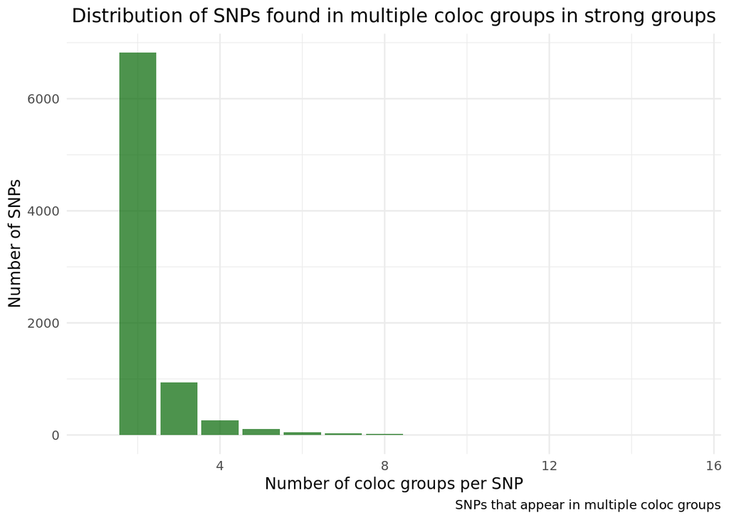

| threshold | num_reused_snps | total_snps |
| --- | --- | --- |
| moderate | 8089 | 335604 |
| strong | 8234 | 312943 |

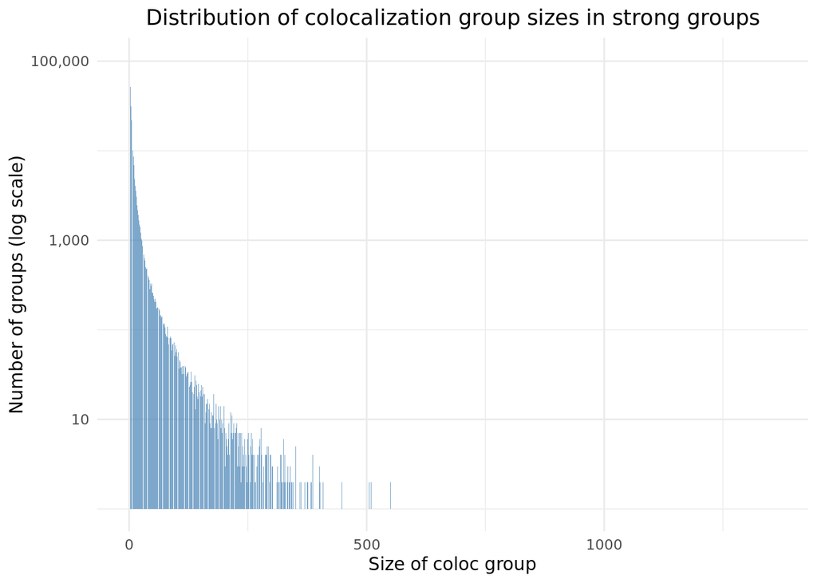

# Universal vs. Modular Pleiotropy

### How many genes are associated with a trait on average?

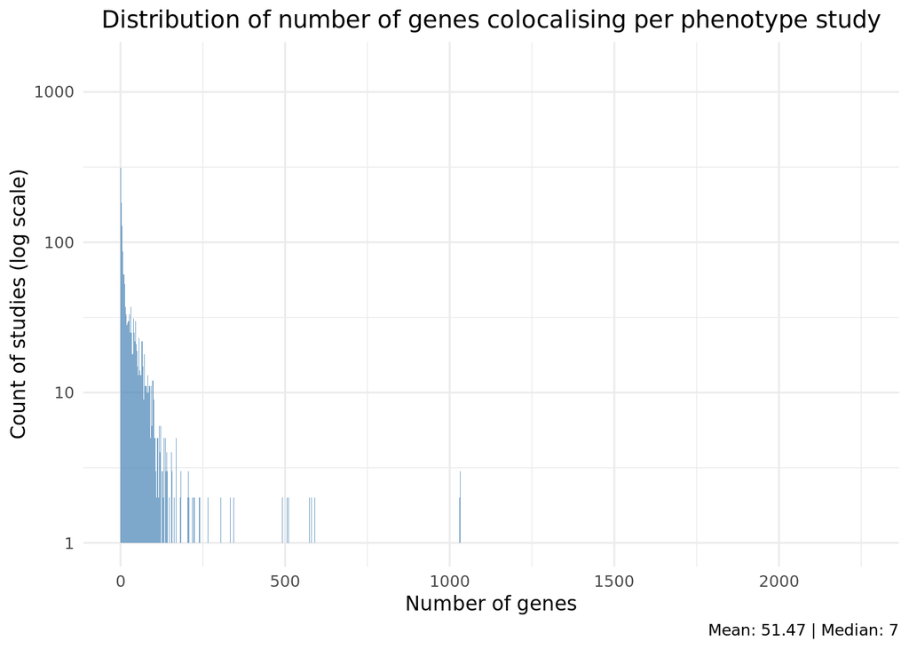

Top 10 studies by number of genes colocalising

| num_genes | study_id | trait_name | sample_size |
| --- | --- | --- | --- |
| 2252 | 1993 | Height | 673878 |
| 2028 | 2869 | Standing height | 461950 |
| 1489 | 1987 | Platelet count | 600968 |
| 1473 | 168 | Appendicular lean mass | 450243 |
| 1369 | 1984 | Mean platelet volume | 694866 |
| 1326 | 3464 | Sitting height | 461536 |
| 1261 | 2006 | Basal metabolic rate | 534045 |
| 1197 | 935 | Mean spheric corpuscular volume | 408112 |
| 1191 | 3143 | Whole body fat-free mass | 454850 |
| 1187 | 3265 | Whole body water mass | 454888 |

Studies with large sample size (>115,082) but small number of genes (<7)

| num_genes | study_id | trait_name | sample_size |
| --- | --- | --- | --- |
| 0 | 153 | COVID-19 (hospitalized vs population) RELEASE 4 | 908,494 |
| 5 | 2464 | Frozen shoulder | 627,998 |
| 4 | 1467 | Thyroid cancer | 491,974 |
| 2 | 1347 | Brain tumor | 491,542 |
| 0 | 1404 | Hypertrophic cardiomyopathy | 489,727 |
| 2 | 1400 | Hearing loss, difficulty in hearing | 489,493 |
| 0 | 1407 | Idiopathic thrombocytopenic purpura | 489,424 |
| 0 | 1410 | Insomnia | 486,627 |
| 3 | 1318 | Irritable bowel syndrome | 486,601 |
| 1 | 1353 | Chronic heart failure | 486,160 |

#### Does this change when we include trans-QTLs?

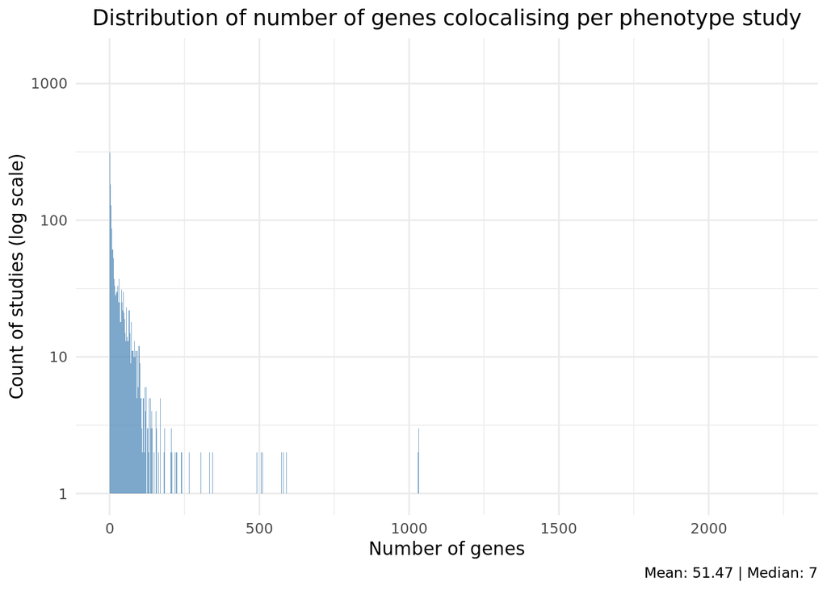

Top 10 studies by number of genes colocalising

| num_genes | study_id | trait_name | sample_size |
| --- | --- | --- | --- |
| 2252 | 1993 | Height | 673878 |
| 2028 | 2869 | Standing height | 461950 |
| 1489 | 1987 | Platelet count | 600968 |
| 1473 | 168 | Appendicular lean mass | 450243 |
| 1369 | 1984 | Mean platelet volume | 694866 |
| 1326 | 3464 | Sitting height | 461536 |
| 1261 | 2006 | Basal metabolic rate | 534045 |
| 1197 | 935 | Mean spheric corpuscular volume | 408112 |
| 1191 | 3143 | Whole body fat-free mass | 454850 |
| 1187 | 3265 | Whole body water mass | 454888 |

Studies with large sample size (>115,082) but small number of genes (<7)

| num_genes | study_id | trait_name | sample_size |
| --- | --- | --- | --- |
| 0 | 153 | COVID-19 (hospitalized vs population) RELEASE 4 | 908,494 |
| 5 | 2464 | Frozen shoulder | 627,998 |
| 4 | 1467 | Thyroid cancer | 491,974 |
| 2 | 1347 | Brain tumor | 491,542 |
| 0 | 1404 | Hypertrophic cardiomyopathy | 489,727 |
| 2 | 1400 | Hearing loss, difficulty in hearing | 489,493 |
| 0 | 1407 | Idiopathic thrombocytopenic purpura | 489,424 |
| 0 | 1410 | Insomnia | 486,627 |
| 3 | 1318 | Irritable bowel syndrome | 486,601 |
| 1 | 1353 | Chronic heart failure | 486,160 |

### Relationship between number of genes colocalising for a study, and the sample size

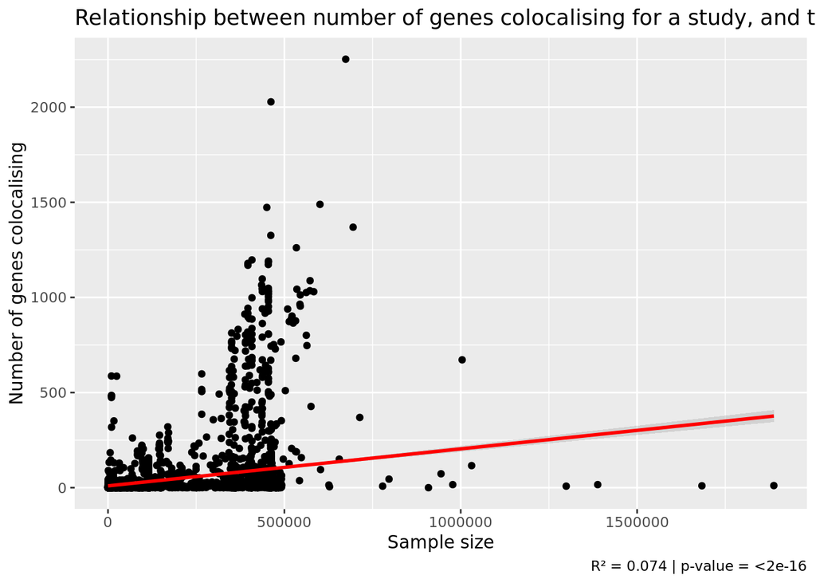

### What about gene-gene modularity?

How can we look into this? Some sort of recreation of epigraph db…

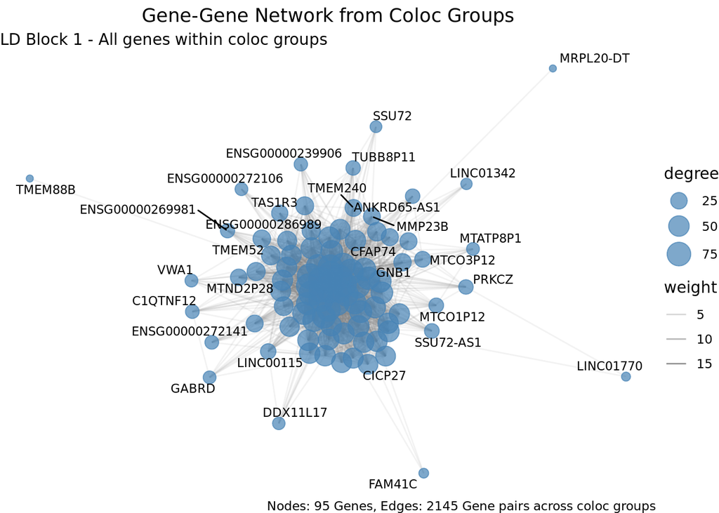

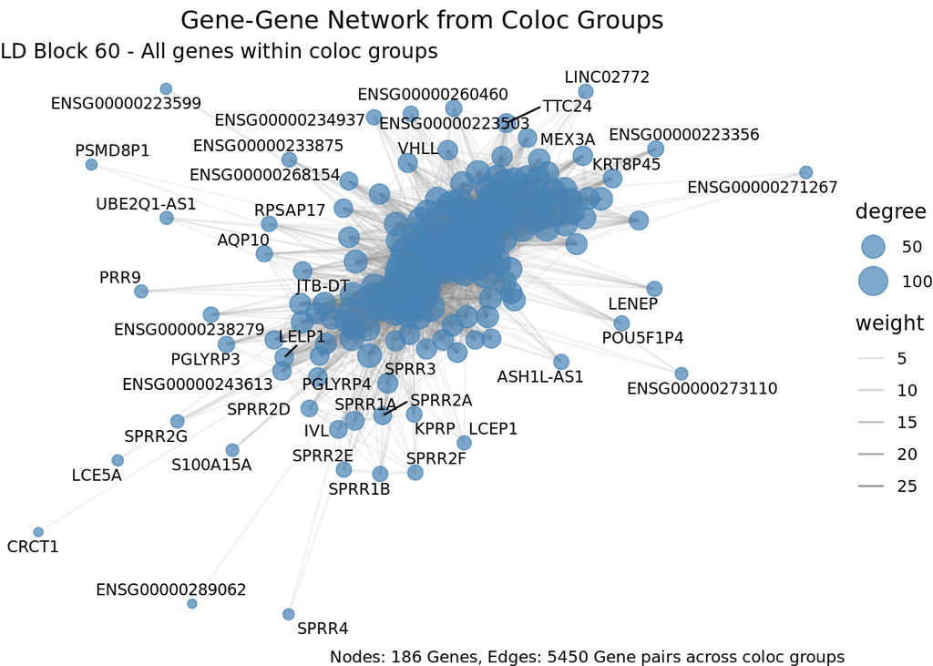

# Random other ideas

### Colocalisation deserts in the genome

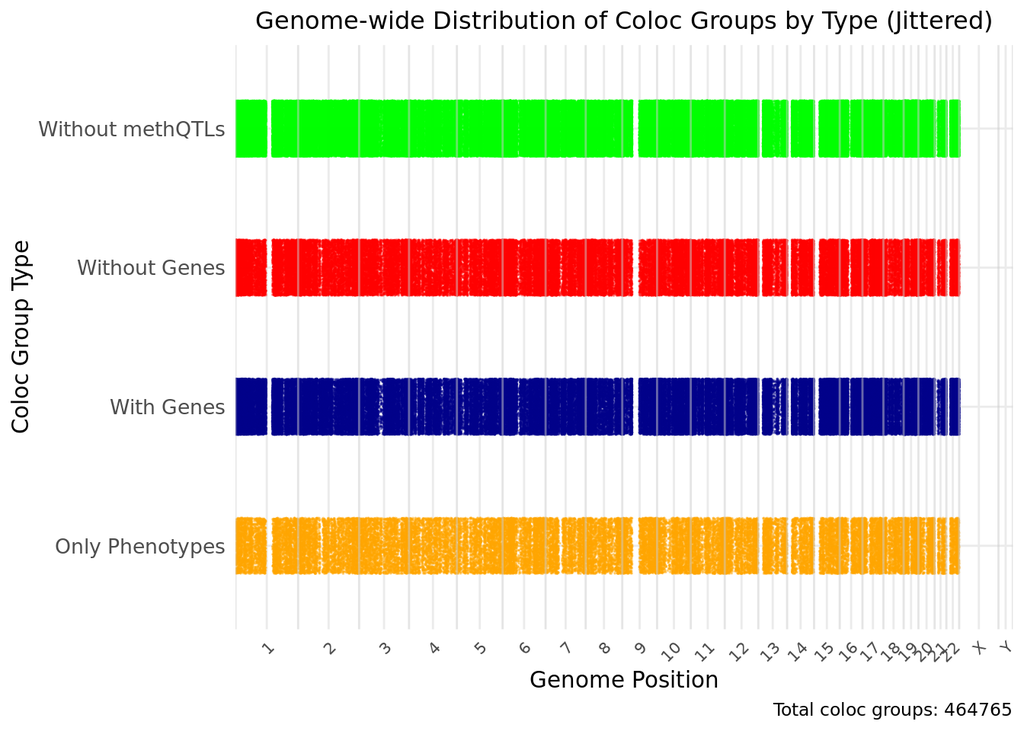

# What fraction of known GWAS hits are no known molecular trait associated with it?

```
## All significant phenotype study extractions: 298425
```

```
## All significant phenotype study extractions without coloc: 32326
```

```
## Significant phenotype study extractions in a phenotype only coloc: 48528
```

```
## All significant non-molecular coloc: 80854
```

```
## Percentage of all significant phenotype study extractions that are not in a molecular coloc: 0.2709357
```

```
## Original all_coloc_groups rows: 3009821
```

```
## Deduplicated rows: 312943
```

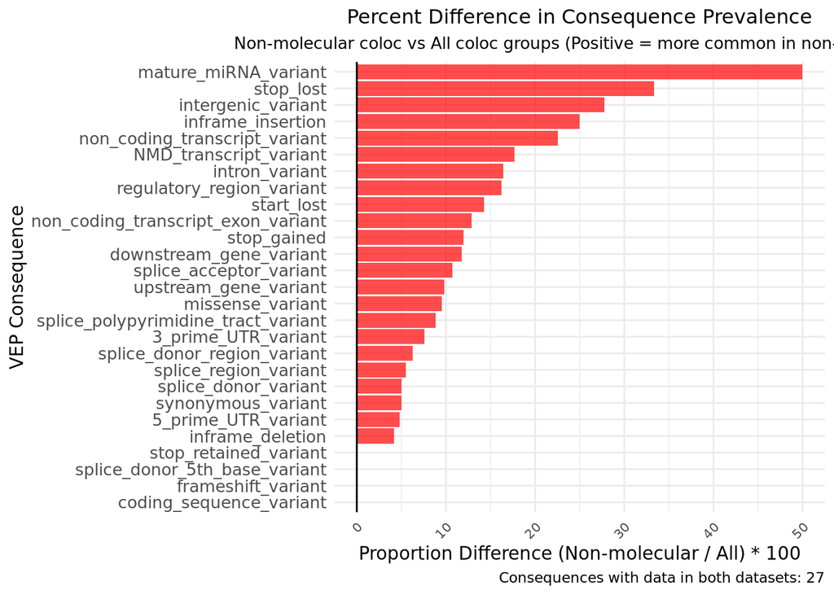

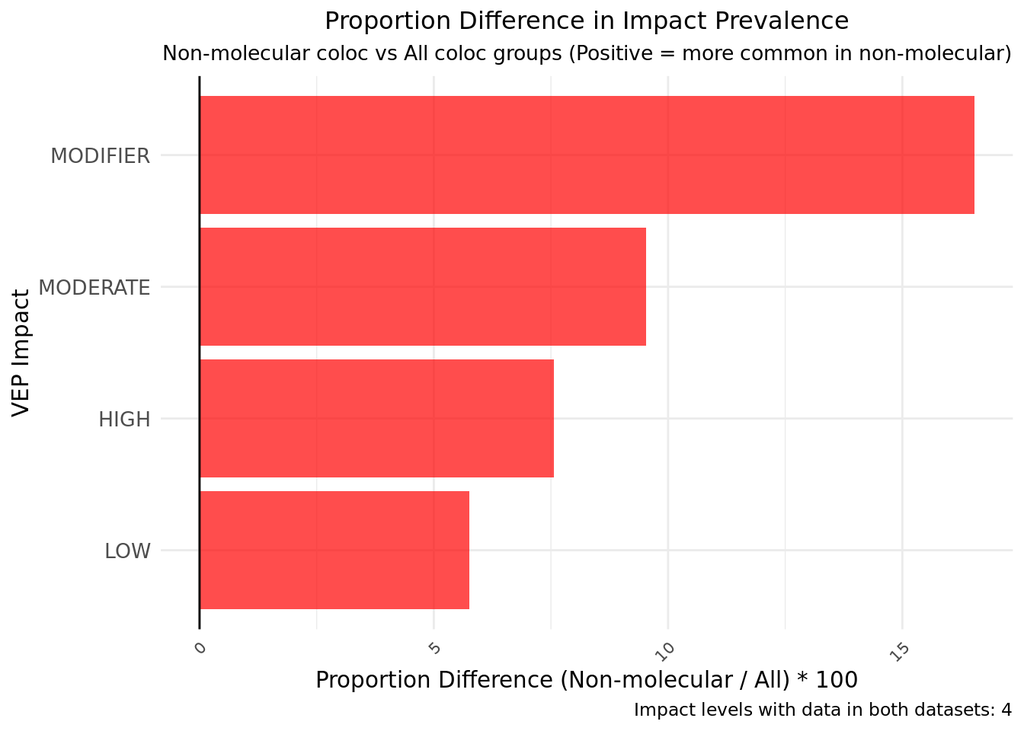

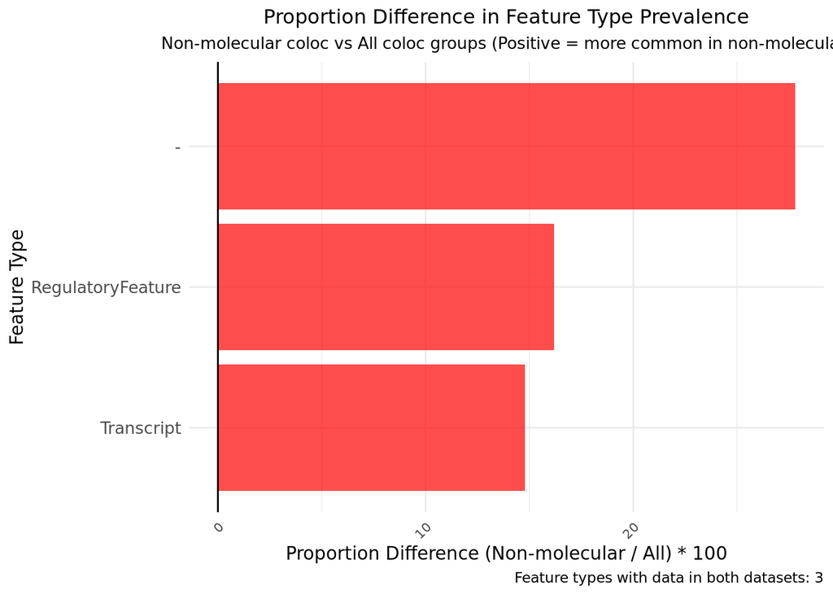

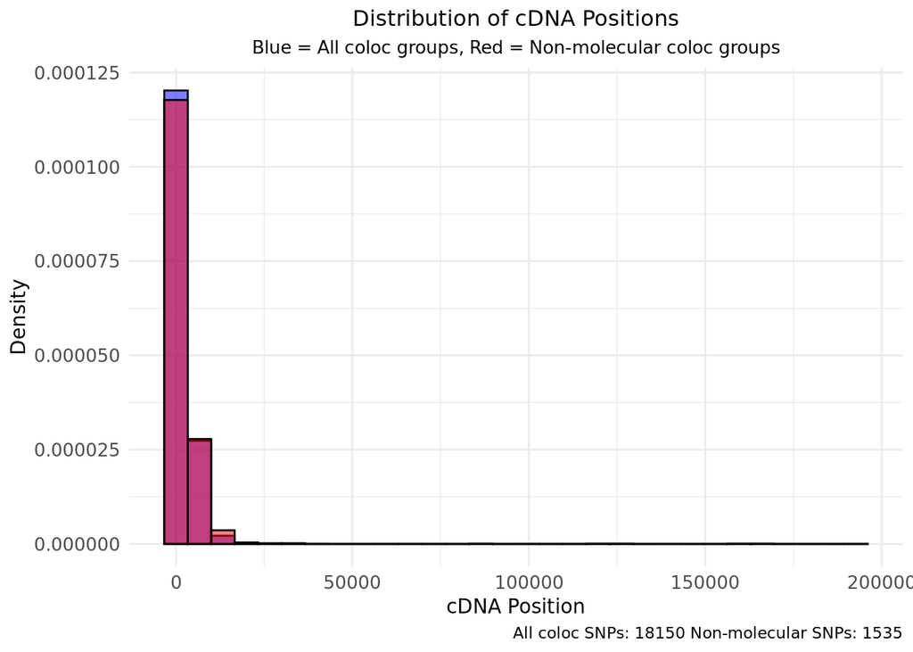

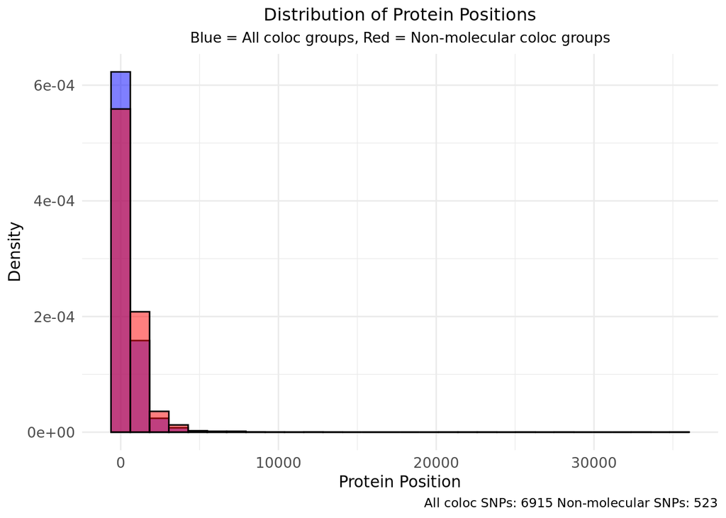

[figure not shown]

# Can we calculate a ‘pleiotropy score’ for each SNP?

### Colocalisation proximity to genes: how can we quantify ‘artefactual’ pleiotropy?